# Hepatitis Mortality Prediction with ML

#### Question

- Predict if a patient will live or die based on the parameters using ML

#### Workflow

- Data Prep
- EDA
- Feature Selection
- Build Model
- Interpret Model
- Serialization

```python
# Load Our EDA Pkgs
import pandas as pd
import numpy as np
```

```python
# Load Data Viz Pkgs
import matplotlib.pyplot as plt
import seaborn as sns
```

1. Class: DIE, LIVE
2. AGE: 10, 20, 30, 40, 50, 60, 70, 80
3. SEX: male, female
4. STEROID: no, yes
5. ANTIVIRALS: no, yes
6. FATIGUE: no, yes
7. MALAISE: no, yes
8. ANOREXIA: no, yes
9. LIVER BIG: no, yes
10. LIVER FIRM: no, yes
11. SPLEEN PALPABLE: no, yes
12. SPIDERS: no, yes
13. ASCITES: no, yes
14. VARICES: no, yes
15. BILIRUBIN: 0.39, 0.80, 1.20, 2.00, 3.00, 4.00
16. ALK PHOSPHATE: 33, 80, 120, 160, 200, 250
17. SGOT: 13, 100, 200, 300, 400, 500,
18. ALBUMIN: 2.1, 3.0, 3.8, 4.5, 5.0, 6.0
19. PROTIME: 10, 20, 30, 40, 50, 60, 70, 80, 90
20. HISTOLOGY: no, yes

```python
# Load Our Dataset
df = pd.read_csv("C:/Users/prera/Downloadshepatitis.data")
```

```python
# Preview the first datapoint
df.head()
```

|  | 2 | 30 | 2.1 | 1 | 2.2 | 2.3 | 2.4 | 2.5 | 1.1 | 2.6 | 2.7 | 2.8 | 2.9 | 2.10 | 1.00 | 85 | 18 | 4.0 | ? | 1.2 |
| --- | --- | --- | --- | --- | --- | --- | --- | --- | --- | --- | --- | --- | --- | --- | --- | --- | --- | --- | --- | --- |
| 0 | 2 | 50 | 1 | 1 | 2 | 1 | 2 | 2 | 1 | 2 | 2 | 2 | 2 | 2 | 0.90 | 135 | 42 | 3.5 | ? | 1 |
| 1 | 2 | 78 | 1 | 2 | 2 | 1 | 2 | 2 | 2 | 2 | 2 | 2 | 2 | 2 | 0.70 | 96 | 32 | 4.0 | ? | 1 |
| 2 | 2 | 31 | 1 | ? | 1 | 2 | 2 | 2 | 2 | 2 | 2 | 2 | 2 | 2 | 0.70 | 46 | 52 | 4.0 | 80 | 1 |
| 3 | 2 | 34 | 1 | 2 | 2 | 2 | 2 | 2 | 2 | 2 | 2 | 2 | 2 | 2 | 1.00 | ? | 200 | 4.0 | ? | 1 |
| 4 | 2 | 34 | 1 | 2 | 2 | 2 | 2 | 2 | 2 | 2 | 2 | 2 | 2 | 2 | 0.90 | 95 | 28 | 4.0 | 75 | 1 |

```python
col_names = ["Class","AGE","SEX","STEROID","ANTIVIRALS","FATIGUE","MALAISE","ANOREXIA","LIVER BIG","LIVER FIRM","SPLEEN PALPABLE","SPIDERS","ASCITES","VARICES","BILIRUBIN","ALK PHOSPHATE","SGOT","ALBUMIN","PROTIME","HISTOLOGY"]
```

```python
df = pd.read_csv("C:/Users/prera/Downloads/hepatitis.data",names=col_names)
df
```

|  | Class | AGE | SEX | STEROID | ANTIVIRALS | FATIGUE | MALAISE | ANOREXIA | LIVER BIG | LIVER FIRM | SPLEEN PALPABLE | SPIDERS | ASCITES | VARICES | BILIRUBIN | ALK PHOSPHATE | SGOT | ALBUMIN | PROTIME | HISTOLOGY |
| --- | --- | --- | --- | --- | --- | --- | --- | --- | --- | --- | --- | --- | --- | --- | --- | --- | --- | --- | --- | --- |
| 0 | 2 | 30 | 2 | 1 | 2 | 2 | 2 | 2 | 1 | 2 | 2 | 2 | 2 | 2 | 1.00 | 85 | 18 | 4.0 | ? | 1 |
| 1 | 2 | 50 | 1 | 1 | 2 | 1 | 2 | 2 | 1 | 2 | 2 | 2 | 2 | 2 | 0.90 | 135 | 42 | 3.5 | ? | 1 |
| 2 | 2 | 78 | 1 | 2 | 2 | 1 | 2 | 2 | 2 | 2 | 2 | 2 | 2 | 2 | 0.70 | 96 | 32 | 4.0 | ? | 1 |
| 3 | 2 | 31 | 1 | ? | 1 | 2 | 2 | 2 | 2 | 2 | 2 | 2 | 2 | 2 | 0.70 | 46 | 52 | 4.0 | 80 | 1 |
| 4 | 2 | 34 | 1 | 2 | 2 | 2 | 2 | 2 | 2 | 2 | 2 | 2 | 2 | 2 | 1.00 | ? | 200 | 4.0 | ? | 1 |
| ... | ... | ... | ... | ... | ... | ... | ... | ... | ... | ... | ... | ... | ... | ... | ... | ... | ... | ... | ... | ... |
| 150 | 1 | 46 | 1 | 2 | 2 | 1 | 1 | 1 | 2 | 2 | 2 | 1 | 1 | 1 | 7.60 | ? | 242 | 3.3 | 50 | 2 |
| 151 | 2 | 44 | 1 | 2 | 2 | 1 | 2 | 2 | 2 | 1 | 2 | 2 | 2 | 2 | 0.90 | 126 | 142 | 4.3 | ? | 2 |
| 152 | 2 | 61 | 1 | 1 | 2 | 1 | 1 | 2 | 1 | 1 | 2 | 1 | 2 | 2 | 0.80 | 75 | 20 | 4.1 | ? | 2 |
| 153 | 2 | 53 | 2 | 1 | 2 | 1 | 2 | 2 | 2 | 2 | 1 | 1 | 2 | 1 | 1.50 | 81 | 19 | 4.1 | 48 | 2 |
| 154 | 1 | 43 | 1 | 2 | 2 | 1 | 2 | 2 | 2 | 2 | 1 | 1 | 1 | 2 | 1.20 | 100 | 19 | 3.1 | 42 | 2 |

155 rows × 20 columns

```python
df.head()
```

|  | Class | AGE | SEX | STEROID | ANTIVIRALS | FATIGUE | MALAISE | ANOREXIA | LIVER BIG | LIVER FIRM | SPLEEN PALPABLE | SPIDERS | ASCITES | VARICES | BILIRUBIN | ALK PHOSPHATE | SGOT | ALBUMIN | PROTIME | HISTOLOGY |
| --- | --- | --- | --- | --- | --- | --- | --- | --- | --- | --- | --- | --- | --- | --- | --- | --- | --- | --- | --- | --- |
| 0 | 2 | 30 | 2 | 1 | 2 | 2 | 2 | 2 | 1 | 2 | 2 | 2 | 2 | 2 | 1.00 | 85 | 18 | 4.0 | ? | 1 |
| 1 | 2 | 50 | 1 | 1 | 2 | 1 | 2 | 2 | 1 | 2 | 2 | 2 | 2 | 2 | 0.90 | 135 | 42 | 3.5 | ? | 1 |
| 2 | 2 | 78 | 1 | 2 | 2 | 1 | 2 | 2 | 2 | 2 | 2 | 2 | 2 | 2 | 0.70 | 96 | 32 | 4.0 | ? | 1 |
| 3 | 2 | 31 | 1 | ? | 1 | 2 | 2 | 2 | 2 | 2 | 2 | 2 | 2 | 2 | 0.70 | 46 | 52 | 4.0 | 80 | 1 |
| 4 | 2 | 34 | 1 | 2 | 2 | 2 | 2 | 2 | 2 | 2 | 2 | 2 | 2 | 2 | 1.00 | ? | 200 | 4.0 | ? | 1 |

```python
# Clean our Column Names
df.columns
```

```
Index(['Class', 'AGE', 'SEX', 'STEROID', 'ANTIVIRALS', 'FATIGUE', 'MALAISE',
       'ANOREXIA', 'LIVER BIG', 'LIVER FIRM', 'SPLEEN PALPABLE', 'SPIDERS',
       'ASCITES', 'VARICES', 'BILIRUBIN', 'ALK PHOSPHATE', 'SGOT', 'ALBUMIN',
       'PROTIME', 'HISTOLOGY'],
      dtype='object')
```

```python
# Convert ot lowercase
df.columns.str.lower().str.replace(' ','_')
```

```
Index(['class', 'age', 'sex', 'steroid', 'antivirals', 'fatigue', 'malaise',
       'anorexia', 'liver_big', 'liver_firm', 'spleen_palpable', 'spiders',
       'ascites', 'varices', 'bilirubin', 'alk_phosphate', 'sgot', 'albumin',
       'protime', 'histology'],
      dtype='object')
```

```python
df.columns = df.columns.str.lower().str.replace(' ','_')
```

```python
df.head()
```

|  | class | age | sex | steroid | antivirals | fatigue | malaise | anorexia | liver_big | liver_firm | spleen_palpable | spiders | ascites | varices | bilirubin | alk_phosphate | sgot | albumin | protime | histology |
| --- | --- | --- | --- | --- | --- | --- | --- | --- | --- | --- | --- | --- | --- | --- | --- | --- | --- | --- | --- | --- |
| 0 | 2 | 30 | 2 | 1 | 2 | 2 | 2 | 2 | 1 | 2 | 2 | 2 | 2 | 2 | 1.00 | 85 | 18 | 4.0 | ? | 1 |
| 1 | 2 | 50 | 1 | 1 | 2 | 1 | 2 | 2 | 1 | 2 | 2 | 2 | 2 | 2 | 0.90 | 135 | 42 | 3.5 | ? | 1 |
| 2 | 2 | 78 | 1 | 2 | 2 | 1 | 2 | 2 | 2 | 2 | 2 | 2 | 2 | 2 | 0.70 | 96 | 32 | 4.0 | ? | 1 |
| 3 | 2 | 31 | 1 | ? | 1 | 2 | 2 | 2 | 2 | 2 | 2 | 2 | 2 | 2 | 0.70 | 46 | 52 | 4.0 | 80 | 1 |
| 4 | 2 | 34 | 1 | 2 | 2 | 2 | 2 | 2 | 2 | 2 | 2 | 2 | 2 | 2 | 1.00 | ? | 200 | 4.0 | ? | 1 |

```python
# Data Types
df.dtypes
```

```
class               int64
age                 int64
sex                 int64
steroid            object
antivirals          int64
fatigue            object
malaise            object
anorexia           object
liver_big          object
liver_firm         object
spleen_palpable    object
spiders            object
ascites            object
varices            object
bilirubin          object
alk_phosphate      object
sgot               object
albumin            object
protime            object
histology           int64
dtype: object
```

```python
# Replace ? with 0
df = df.replace('?',0)
```

```python
df.head()
```

|  | class | age | sex | steroid | antivirals | fatigue | malaise | anorexia | liver_big | liver_firm | spleen_palpable | spiders | ascites | varices | bilirubin | alk_phosphate | sgot | albumin | protime | histology |
| --- | --- | --- | --- | --- | --- | --- | --- | --- | --- | --- | --- | --- | --- | --- | --- | --- | --- | --- | --- | --- |
| 0 | 2 | 30 | 2 | 1 | 2 | 2 | 2 | 2 | 1 | 2 | 2 | 2 | 2 | 2 | 1.00 | 85 | 18 | 4.0 | 0 | 1 |
| 1 | 2 | 50 | 1 | 1 | 2 | 1 | 2 | 2 | 1 | 2 | 2 | 2 | 2 | 2 | 0.90 | 135 | 42 | 3.5 | 0 | 1 |
| 2 | 2 | 78 | 1 | 2 | 2 | 1 | 2 | 2 | 2 | 2 | 2 | 2 | 2 | 2 | 0.70 | 96 | 32 | 4.0 | 0 | 1 |
| 3 | 2 | 31 | 1 | 0 | 1 | 2 | 2 | 2 | 2 | 2 | 2 | 2 | 2 | 2 | 0.70 | 46 | 52 | 4.0 | 80 | 1 |
| 4 | 2 | 34 | 1 | 2 | 2 | 2 | 2 | 2 | 2 | 2 | 2 | 2 | 2 | 2 | 1.00 | 0 | 200 | 4.0 | 0 | 1 |

```python
df.dtypes
```

```
class               int64
age                 int64
sex                 int64
steroid            object
antivirals          int64
fatigue            object
malaise            object
anorexia           object
liver_big          object
liver_firm         object
spleen_palpable    object
spiders            object
ascites            object
varices            object
bilirubin          object
alk_phosphate      object
sgot               object
albumin            object
protime            object
histology           int64
dtype: object
```

```python
# How many columns with object
sum(df.dtypes == 'object')
```

```
15
```

```python
df.columns[df.dtypes == 'object']
```

```
Index(['steroid', 'fatigue', 'malaise', 'anorexia', 'liver_big', 'liver_firm',
       'spleen_palpable', 'spiders', 'ascites', 'varices', 'bilirubin',
       'alk_phosphate', 'sgot', 'albumin', 'protime'],
      dtype='object')
```

```python
# Casting
# Convert from one dt to another
df[['steroid', 'fatigue', 'malaise', 'anorexia', 'liver_big', 'liver_firm',
       'spleen_palpable', 'spiders', 'ascites', 'varices',
       'alk_phosphate', 'sgot', 'protime']] = df[['steroid', 'fatigue', 'malaise', 'anorexia', 'liver_big', 'liver_firm',
       'spleen_palpable', 'spiders', 'ascites', 'varices',
       'alk_phosphate', 'sgot', 'protime']].astype(int)
```

```python
df.dtypes
```

```
class               int64
age                 int64
sex                 int64
steroid             int32
antivirals          int64
fatigue             int32
malaise             int32
anorexia            int32
liver_big           int32
liver_firm          int32
spleen_palpable     int32
spiders             int32
ascites             int32
varices             int32
bilirubin          object
alk_phosphate       int32
sgot                int32
albumin            object
protime             int32
histology           int64
dtype: object
```

```python
df[['bilirubin','albumin']] = df[['bilirubin','albumin']].astype(float)
```

```python
df.dtypes
```

```
class                int64
age                  int64
sex                  int64
steroid              int32
antivirals           int64
fatigue              int32
malaise              int32
anorexia             int32
liver_big            int32
liver_firm           int32
spleen_palpable      int32
spiders              int32
ascites              int32
varices              int32
bilirubin          float64
alk_phosphate        int32
sgot                 int32
albumin            float64
protime              int32
histology            int64
dtype: object
```

#### Narative

- Most of the data were in objects
- Two of them were in float

```python
### Count of each row
df.count()
```

```
class              155
age                155
sex                155
steroid            155
antivirals         155
fatigue            155
malaise            155
anorexia           155
liver_big          155
liver_firm         155
spleen_palpable    155
spiders            155
ascites            155
varices            155
bilirubin          155
alk_phosphate      155
sgot               155
albumin            155
protime            155
histology          155
dtype: int64
```

```python
# Shape of dataset
df.shape
```

```
(155, 20)
```

```python
### Missing Values
df.isnull().sum()
```

```
class              0
age                0
sex                0
steroid            0
antivirals         0
fatigue            0
malaise            0
anorexia           0
liver_big          0
liver_firm         0
spleen_palpable    0
spiders            0
ascites            0
varices            0
bilirubin          0
alk_phosphate      0
sgot               0
albumin            0
protime            0
histology          0
dtype: int64
```

#### EDA

- Descriptive analytics

```python
df.describe()
```

|  | class | age | sex | steroid | antivirals | fatigue | malaise | anorexia | liver_big | liver_firm | spleen_palpable | spiders | ascites | varices | bilirubin | alk_phosphate | sgot | albumin | protime | histology |
| --- | --- | --- | --- | --- | --- | --- | --- | --- | --- | --- | --- | --- | --- | --- | --- | --- | --- | --- | --- | --- |
| count | 155.000000 | 155.000000 | 155.000000 | 155.000000 | 155.000000 | 155.000000 | 155.000000 | 155.000000 | 155.000000 | 155.000000 | 155.000000 | 155.000000 | 155.000000 | 155.000000 | 155.000000 | 155.000000 | 155.000000 | 155.000000 | 155.000000 | 155.000000 |
| mean | 1.793548 | 41.200000 | 1.103226 | 1.496774 | 1.845161 | 1.341935 | 1.593548 | 1.780645 | 1.709677 | 1.470968 | 1.741935 | 1.606452 | 1.806452 | 1.819355 | 1.372258 | 85.619355 | 83.677419 | 3.423226 | 35.116129 | 1.451613 |
| std | 0.406070 | 12.565878 | 0.305240 | 0.514393 | 0.362923 | 0.489350 | 0.505769 | 0.430508 | 0.580727 | 0.627401 | 0.507588 | 0.552406 | 0.471207 | 0.462503 | 1.219992 | 62.061686 | 89.527688 | 1.318343 | 35.221923 | 0.499266 |
| min | 1.000000 | 7.000000 | 1.000000 | 0.000000 | 1.000000 | 0.000000 | 0.000000 | 0.000000 | 0.000000 | 0.000000 | 0.000000 | 0.000000 | 0.000000 | 0.000000 | 0.000000 | 0.000000 | 0.000000 | 0.000000 | 0.000000 | 1.000000 |
| 25% | 2.000000 | 32.000000 | 1.000000 | 1.000000 | 2.000000 | 1.000000 | 1.000000 | 2.000000 | 2.000000 | 1.000000 | 2.000000 | 1.000000 | 2.000000 | 2.000000 | 0.700000 | 51.000000 | 30.500000 | 3.050000 | 0.000000 | 1.000000 |
| 50% | 2.000000 | 39.000000 | 1.000000 | 2.000000 | 2.000000 | 1.000000 | 2.000000 | 2.000000 | 2.000000 | 2.000000 | 2.000000 | 2.000000 | 2.000000 | 2.000000 | 1.000000 | 84.000000 | 55.000000 | 3.900000 | 35.000000 | 1.000000 |
| 75% | 2.000000 | 50.000000 | 1.000000 | 2.000000 | 2.000000 | 2.000000 | 2.000000 | 2.000000 | 2.000000 | 2.000000 | 2.000000 | 2.000000 | 2.000000 | 2.000000 | 1.500000 | 119.500000 | 99.000000 | 4.200000 | 65.000000 | 2.000000 |
| max | 2.000000 | 78.000000 | 2.000000 | 2.000000 | 2.000000 | 2.000000 | 2.000000 | 2.000000 | 2.000000 | 2.000000 | 2.000000 | 2.000000 | 2.000000 | 2.000000 | 8.000000 | 295.000000 | 648.000000 | 6.400000 | 100.000000 | 2.000000 |

```python
target_label = {"Die":1,"Live":2}
```

```python
# Value counts
df['class'].value_counts()
```

```
2    123
1     32
Name: class, dtype: int64
```

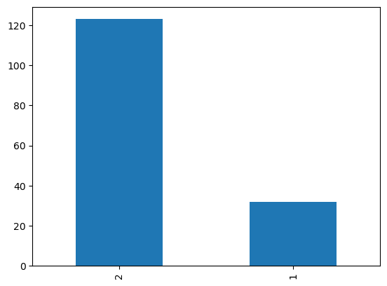

```python
# Plot of Count
df['class'].value_counts().plot(kind='bar')
```

```python
### How many are males(1) and females(2)
df['sex'].unique()
```

```
array([2, 1], dtype=int64)
```

```python
df['sex'].value_counts()
```

```
1    139
2     16
Name: sex, dtype: int64
```

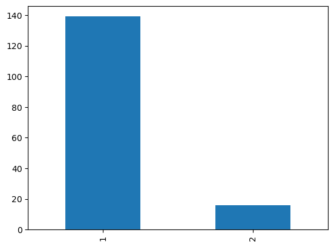

```python
df['sex'].value_counts().plot(kind='bar')
```

### Narative

- There are more males than females in ourdataset

#### Frequency Distribution Table using the Age Range

```python
df['age'].max()
```

```
78
```

```python
df['age'].min()
```

```
7
```

```python
labels = ["Less than 10","10-20","20-30","30-40","40-50","50-60","60-70","70 and more"]
bins= [0,10,20,30,40,50,60,70,80]
freq_df = df.groupby(pd.cut(df['age'],bins=bins,labels=labels)).size()
```

```python
freq_df
```

```
age
Less than 10     1
10-20            3
20-30           29
30-40           50
40-50           35
50-60           24
60-70           11
70 and more      2
dtype: int64
```

```python
freq_df = freq_df.reset_index(name='count')
```

```python
freq_df
```

|  | age | count |
| --- | --- | --- |
| 0 | Less than 10 | 1 |
| 1 | 10-20 | 3 |
| 2 | 20-30 | 29 |
| 3 | 30-40 | 50 |
| 4 | 40-50 | 35 |
| 5 | 50-60 | 24 |
| 6 | 60-70 | 11 |
| 7 | 70 and more | 2 |

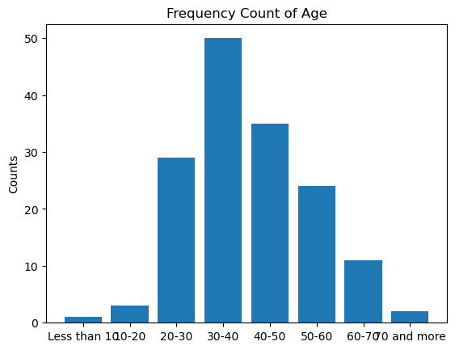

```python
# Plot of Freq Table
plt.bar(freq_df['age'],freq_df['count'])
plt.ylabel('Counts')
plt.title('Frequency Count of Age')
plt.show()
```

### Narative

- Highest prevalence of Hepatitis is from 30-40 followed by 40-50
- The least is individual under 10, and elderly above 70

### Checking for Outliers

- Univariate Analysis
- Multivariate Analysis

#### Methods

- Boxplot(Uni)
- Scatterplot (Multi)
- Z-score
- IQR Interquartile Range

```python
# Using Boxplot for Univariate Outlier Detection
import seaborn as sns
```

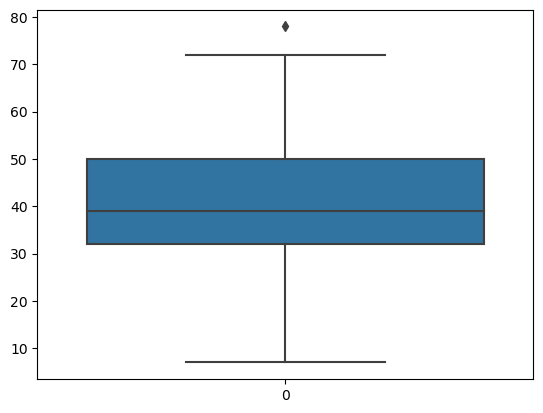

```python
sns.boxplot(df['age'])
```

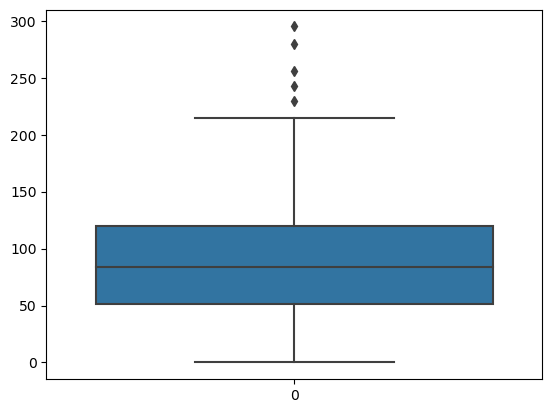

```python
sns.boxplot(df['alk_phosphate'])
```

```python
df[df['age'] == 78]
```

|  | class | age | sex | steroid | antivirals | fatigue | malaise | anorexia | liver_big | liver_firm | spleen_palpable | spiders | ascites | varices | bilirubin | alk_phosphate | sgot | albumin | protime | histology |
| --- | --- | --- | --- | --- | --- | --- | --- | --- | --- | --- | --- | --- | --- | --- | --- | --- | --- | --- | --- | --- |
| 2 | 2 | 78 | 1 | 2 | 2 | 1 | 2 | 2 | 2 | 2 | 2 | 2 | 2 | 2 | 0.7 | 96 | 32 | 4.0 | 0 | 1 |

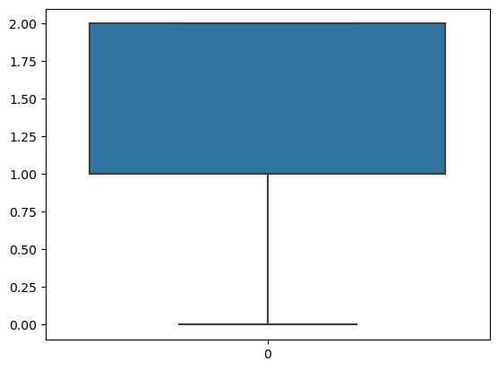

```python
# using boxplot for outlier detection
sns.boxplot(df['steroid'])
```

#### using Interquartile Range(IQR)

- H-Spread/Mid_spread
- Measures the statistical dispersion/spread
- IQR = Quantile 3(75) - Quantile 1(25)

```python
q1 = df.quantile(0.25)
q3 = df.quantile(0.75)
```

```python
IQR = q3 - q1
```

```python
IQR
```

```
class               0.00
age                18.00
sex                 0.00
steroid             1.00
antivirals          0.00
fatigue             1.00
malaise             1.00
anorexia            0.00
liver_big           0.00
liver_firm          1.00
spleen_palpable     0.00
spiders             1.00
ascites             0.00
varices             0.00
bilirubin           0.80
alk_phosphate      68.50
sgot               68.50
albumin             1.15
protime            65.00
histology           1.00
dtype: float64
```

```python
### Get the actual datapoint that is an outlier
(df < (q1 -1.5 * IQR)) | (df >(q3 + 1.5 * IQR))
```

|  | class | age | sex | steroid | antivirals | fatigue | malaise | anorexia | liver_big | liver_firm | spleen_palpable | spiders | ascites | varices | bilirubin | alk_phosphate | sgot | albumin | protime | histology |
| --- | --- | --- | --- | --- | --- | --- | --- | --- | --- | --- | --- | --- | --- | --- | --- | --- | --- | --- | --- | --- |
| 0 | False | False | True | False | False | False | False | False | True | False | False | False | False | False | False | False | False | False | False | False |
| 1 | False | False | False | False | False | False | False | False | True | False | False | False | False | False | False | False | False | False | False | False |
| 2 | False | True | False | False | False | False | False | False | False | False | False | False | False | False | False | False | False | False | False | False |
| 3 | False | False | False | False | True | False | False | False | False | False | False | False | False | False | False | False | False | False | False | False |
| 4 | False | False | False | False | False | False | False | False | False | False | False | False | False | False | False | False | False | False | False | False |
| ... | ... | ... | ... | ... | ... | ... | ... | ... | ... | ... | ... | ... | ... | ... | ... | ... | ... | ... | ... | ... |
| 150 | True | False | False | False | False | False | False | True | False | False | False | False | True | True | True | False | True | False | False | False |
| 151 | False | False | False | False | False | False | False | False | False | False | False | False | False | False | False | False | False | False | False | False |
| 152 | False | False | False | False | False | False | False | False | True | False | False | False | False | False | False | False | False | False | False | False |
| 153 | False | False | True | False | False | False | False | False | False | False | True | False | False | True | False | False | False | False | False | False |
| 154 | True | False | False | False | False | False | False | False | False | False | True | False | True | False | False | False | False | False | False | False |

155 rows × 20 columns

### Narative

- The data points with true are the outlier

##### Solution

- Remove
- Change
- Ignore

```python
df_no_outlier = df[~((df < (q1 -1.5 * IQR)) | (df >(q3 + 1.5 * IQR))).any(axis=1)]
```

```python
df_no_outlier
```

|  | class | age | sex | steroid | antivirals | fatigue | malaise | anorexia | liver_big | liver_firm | spleen_palpable | spiders | ascites | varices | bilirubin | alk_phosphate | sgot | albumin | protime | histology |
| --- | --- | --- | --- | --- | --- | --- | --- | --- | --- | --- | --- | --- | --- | --- | --- | --- | --- | --- | --- | --- |
| 4 | 2 | 34 | 1 | 2 | 2 | 2 | 2 | 2 | 2 | 2 | 2 | 2 | 2 | 2 | 1.0 | 0 | 200 | 4.0 | 0 | 1 |
| 5 | 2 | 34 | 1 | 2 | 2 | 2 | 2 | 2 | 2 | 2 | 2 | 2 | 2 | 2 | 0.9 | 95 | 28 | 4.0 | 75 | 1 |
| 8 | 2 | 39 | 1 | 2 | 2 | 1 | 2 | 2 | 2 | 1 | 2 | 2 | 2 | 2 | 0.7 | 0 | 48 | 4.4 | 0 | 1 |
| 9 | 2 | 30 | 1 | 2 | 2 | 2 | 2 | 2 | 2 | 2 | 2 | 2 | 2 | 2 | 1.0 | 0 | 120 | 3.9 | 0 | 1 |
| 13 | 2 | 30 | 1 | 2 | 2 | 1 | 2 | 2 | 2 | 1 | 2 | 2 | 2 | 2 | 2.2 | 57 | 144 | 4.9 | 78 | 1 |
| 16 | 2 | 66 | 1 | 2 | 2 | 1 | 2 | 2 | 2 | 2 | 2 | 2 | 2 | 2 | 1.2 | 102 | 53 | 4.3 | 0 | 1 |
| 17 | 2 | 40 | 1 | 1 | 2 | 1 | 2 | 2 | 2 | 1 | 2 | 2 | 2 | 2 | 0.6 | 62 | 166 | 4.0 | 63 | 1 |
| 18 | 2 | 38 | 1 | 2 | 2 | 2 | 2 | 2 | 2 | 2 | 2 | 2 | 2 | 2 | 0.7 | 53 | 42 | 4.1 | 85 | 2 |
| 22 | 2 | 31 | 1 | 2 | 2 | 2 | 2 | 2 | 2 | 2 | 2 | 2 | 2 | 2 | 1.0 | 85 | 20 | 4.0 | 100 | 1 |
| 23 | 2 | 42 | 1 | 2 | 2 | 2 | 2 | 2 | 2 | 2 | 2 | 2 | 2 | 2 | 0.9 | 60 | 63 | 4.7 | 47 | 1 |
| 25 | 2 | 27 | 1 | 1 | 2 | 1 | 1 | 2 | 2 | 2 | 2 | 2 | 2 | 2 | 0.8 | 95 | 46 | 3.8 | 100 | 1 |
| 34 | 2 | 35 | 1 | 2 | 2 | 1 | 2 | 2 | 2 | 2 | 2 | 2 | 2 | 2 | 0.9 | 58 | 92 | 4.3 | 73 | 1 |
| 38 | 2 | 42 | 1 | 1 | 2 | 2 | 2 | 2 | 2 | 2 | 2 | 2 | 2 | 2 | 1.0 | 85 | 14 | 4.0 | 100 | 1 |
| 42 | 2 | 33 | 1 | 2 | 2 | 2 | 2 | 2 | 2 | 2 | 2 | 2 | 2 | 2 | 1.0 | 46 | 90 | 4.4 | 60 | 1 |
| 43 | 2 | 56 | 1 | 1 | 2 | 1 | 2 | 2 | 2 | 2 | 2 | 2 | 2 | 2 | 0.7 | 71 | 18 | 4.4 | 100 | 1 |
| 45 | 2 | 28 | 1 | 2 | 2 | 1 | 1 | 2 | 2 | 2 | 2 | 2 | 2 | 2 | 0.7 | 74 | 110 | 4.4 | 0 | 1 |
| 46 | 2 | 37 | 1 | 1 | 2 | 2 | 2 | 2 | 2 | 1 | 2 | 1 | 2 | 2 | 0.6 | 80 | 80 | 3.8 | 0 | 1 |
| 50 | 2 | 39 | 1 | 1 | 2 | 2 | 2 | 2 | 2 | 2 | 2 | 2 | 2 | 2 | 0.9 | 85 | 60 | 4.0 | 0 | 1 |
| 51 | 2 | 39 | 1 | 2 | 2 | 2 | 2 | 2 | 2 | 2 | 2 | 2 | 2 | 2 | 1.0 | 85 | 20 | 4.0 | 0 | 1 |
| 52 | 2 | 44 | 1 | 2 | 2 | 2 | 2 | 2 | 2 | 2 | 2 | 2 | 2 | 2 | 0.6 | 110 | 145 | 4.4 | 70 | 1 |
| 54 | 2 | 30 | 1 | 2 | 2 | 1 | 2 | 2 | 2 | 2 | 2 | 2 | 2 | 2 | 0.7 | 50 | 78 | 4.2 | 74 | 1 |
| 60 | 2 | 37 | 1 | 2 | 2 | 2 | 2 | 2 | 2 | 2 | 2 | 2 | 2 | 2 | 0.7 | 26 | 58 | 4.5 | 100 | 1 |
| 61 | 2 | 32 | 1 | 2 | 2 | 2 | 2 | 2 | 2 | 2 | 2 | 2 | 2 | 2 | 0.7 | 102 | 64 | 4.0 | 90 | 1 |
| 64 | 2 | 49 | 1 | 2 | 2 | 1 | 1 | 2 | 2 | 2 | 2 | 2 | 2 | 2 | 0.8 | 103 | 43 | 3.5 | 66 | 1 |
| 65 | 2 | 27 | 1 | 2 | 2 | 2 | 2 | 2 | 2 | 2 | 2 | 2 | 2 | 2 | 0.8 | 0 | 38 | 4.2 | 0 | 1 |
| 66 | 2 | 56 | 1 | 1 | 2 | 2 | 2 | 2 | 2 | 2 | 2 | 2 | 2 | 2 | 0.7 | 62 | 33 | 3.0 | 0 | 1 |
| 68 | 2 | 39 | 1 | 2 | 2 | 1 | 2 | 2 | 2 | 2 | 2 | 2 | 2 | 2 | 1.0 | 34 | 15 | 4.0 | 54 | 1 |
| 69 | 2 | 44 | 1 | 1 | 2 | 1 | 1 | 2 | 2 | 2 | 2 | 2 | 2 | 2 | 1.6 | 68 | 68 | 3.7 | 0 | 1 |
| 70 | 2 | 24 | 1 | 2 | 2 | 2 | 2 | 2 | 2 | 2 | 2 | 2 | 2 | 2 | 0.8 | 82 | 39 | 4.3 | 0 | 1 |
| 74 | 2 | 50 | 1 | 2 | 2 | 2 | 2 | 2 | 2 | 2 | 2 | 2 | 2 | 2 | 1.5 | 100 | 100 | 5.3 | 0 | 1 |
| 79 | 2 | 28 | 1 | 2 | 2 | 2 | 2 | 2 | 2 | 2 | 2 | 2 | 2 | 2 | 0.7 | 85 | 31 | 4.9 | 0 | 1 |
| 82 | 2 | 30 | 1 | 1 | 2 | 2 | 2 | 2 | 2 | 2 | 2 | 2 | 2 | 2 | 0.7 | 100 | 31 | 4.0 | 100 | 1 |
| 93 | 2 | 52 | 1 | 1 | 2 | 2 | 2 | 2 | 2 | 2 | 2 | 2 | 2 | 2 | 1.5 | 0 | 69 | 2.9 | 0 | 2 |
| 96 | 2 | 30 | 1 | 1 | 2 | 1 | 1 | 2 | 2 | 1 | 2 | 1 | 2 | 2 | 0.8 | 147 | 128 | 3.9 | 100 | 2 |
| 112 | 2 | 52 | 1 | 1 | 2 | 1 | 2 | 2 | 2 | 2 | 2 | 2 | 2 | 2 | 1.0 | 85 | 30 | 4.0 | 0 | 2 |
| 114 | 2 | 36 | 1 | 1 | 2 | 2 | 2 | 2 | 2 | 2 | 2 | 2 | 2 | 2 | 1.1 | 141 | 75 | 3.3 | 0 | 2 |
| 116 | 2 | 24 | 1 | 1 | 2 | 1 | 2 | 2 | 2 | 2 | 2 | 2 | 2 | 2 | 1.0 | 0 | 34 | 4.1 | 0 | 2 |
| 117 | 2 | 50 | 1 | 2 | 2 | 2 | 2 | 2 | 2 | 2 | 2 | 2 | 2 | 2 | 1.0 | 139 | 81 | 3.9 | 62 | 2 |
| 130 | 2 | 54 | 1 | 2 | 2 | 2 | 2 | 2 | 2 | 2 | 2 | 2 | 2 | 2 | 1.0 | 85 | 30 | 4.5 | 0 | 2 |
| 145 | 2 | 31 | 1 | 1 | 2 | 1 | 2 | 2 | 2 | 2 | 2 | 2 | 2 | 2 | 1.2 | 75 | 173 | 4.2 | 54 | 2 |
| 148 | 2 | 20 | 1 | 1 | 2 | 2 | 2 | 2 | 2 | 0 | 2 | 2 | 2 | 2 | 0.9 | 89 | 152 | 4.0 | 0 | 2 |
| 149 | 2 | 36 | 1 | 2 | 2 | 2 | 2 | 2 | 2 | 2 | 2 | 2 | 2 | 2 | 0.6 | 120 | 30 | 4.0 | 0 | 2 |
| 151 | 2 | 44 | 1 | 2 | 2 | 1 | 2 | 2 | 2 | 1 | 2 | 2 | 2 | 2 | 0.9 | 126 | 142 | 4.3 | 0 | 2 |

```python
print(df.shape)
print(df_no_outlier.shape)
```

```
(155, 20)
(43, 20)
```

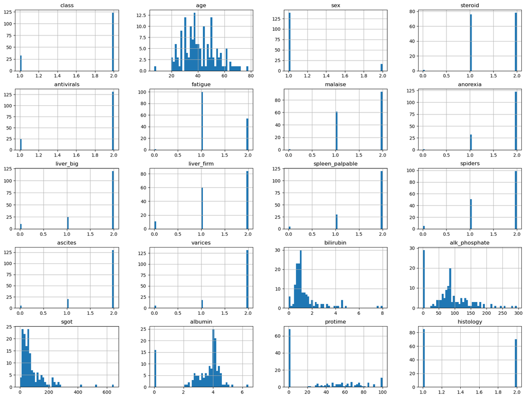

```python
### Plot of distribution of data
df.hist(bins=50,figsize=(20,15))
plt.show()
```

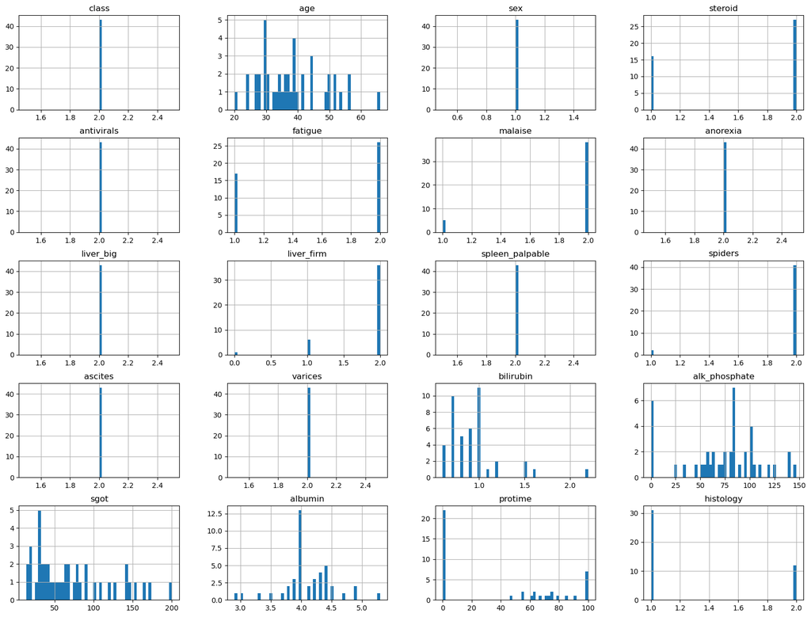

```python
### Plot of distribution of data
df_no_outlier.hist(bins=50,figsize=(20,15))
plt.show()
```

#### Feature Selection and Importance

- SelectKbest
  - Strong relation with the output/target
- Recursive Feature Elimination

```python
from sklearn.feature_selection import SelectKBest
from sklearn.feature_selection  import chi2
```

```python
# Features and Labels
df.head()
```

|  | class | age | sex | steroid | antivirals | fatigue | malaise | anorexia | liver_big | liver_firm | spleen_palpable | spiders | ascites | varices | bilirubin | alk_phosphate | sgot | albumin | protime | histology |
| --- | --- | --- | --- | --- | --- | --- | --- | --- | --- | --- | --- | --- | --- | --- | --- | --- | --- | --- | --- | --- |
| 0 | 2 | 30 | 2 | 1 | 2 | 2 | 2 | 2 | 1 | 2 | 2 | 2 | 2 | 2 | 1.0 | 85 | 18 | 4.0 | 0 | 1 |
| 1 | 2 | 50 | 1 | 1 | 2 | 1 | 2 | 2 | 1 | 2 | 2 | 2 | 2 | 2 | 0.9 | 135 | 42 | 3.5 | 0 | 1 |
| 2 | 2 | 78 | 1 | 2 | 2 | 1 | 2 | 2 | 2 | 2 | 2 | 2 | 2 | 2 | 0.7 | 96 | 32 | 4.0 | 0 | 1 |
| 3 | 2 | 31 | 1 | 0 | 1 | 2 | 2 | 2 | 2 | 2 | 2 | 2 | 2 | 2 | 0.7 | 46 | 52 | 4.0 | 80 | 1 |
| 4 | 2 | 34 | 1 | 2 | 2 | 2 | 2 | 2 | 2 | 2 | 2 | 2 | 2 | 2 | 1.0 | 0 | 200 | 4.0 | 0 | 1 |

```python
df.columns
```

```
Index(['class', 'age', 'sex', 'steroid', 'antivirals', 'fatigue', 'malaise',
       'anorexia', 'liver_big', 'liver_firm', 'spleen_palpable', 'spiders',
       'ascites', 'varices', 'bilirubin', 'alk_phosphate', 'sgot', 'albumin',
       'protime', 'histology'],
      dtype='object')
```

```python
xfeatures = df[['age', 'sex', 'steroid', 'antivirals', 'fatigue', 'malaise',
       'anorexia', 'liver_big', 'liver_firm', 'spleen_palpable', 'spiders',
       'ascites', 'varices', 'bilirubin', 'alk_phosphate', 'sgot', 'albumin',
       'protime', 'histology']]
ylabels = df['class']
```

```python
# using Skbest
skb = SelectKBest(score_func=chi2,k=10)
best_feature_fit = skb.fit(xfeatures,ylabels)
```

```python
# Highest score shows the best fit
print("Scores",best_feature_fit.scores_)
```

```
Scores [ 28.47481919   0.38948319   0.3995129    0.18634161   2.34643234
   2.46803203   0.19648065   0.31698209   0.9867095    0.74535155
   3.18940804   2.09639954   1.12812176  30.10247172  17.88270548
  47.38820795   6.87318606 130.18332457   3.01854675]
```

```python
# Transform(Optional)
bf_02 = best_feature_fit.transform(xfeatures)
```

```python
bf_02
```

```
array([[30. ,  2. ,  2. , ...,  4. ,  0. ,  1. ],
       [50. ,  1. ,  2. , ...,  3.5,  0. ,  1. ],
       [78. ,  1. ,  2. , ...,  4. ,  0. ,  1. ],
       ...,
       [61. ,  1. ,  1. , ...,  4.1,  0. ,  2. ],
       [53. ,  1. ,  2. , ...,  4.1, 48. ,  2. ],
       [43. ,  1. ,  2. , ...,  3.1, 42. ,  2. ]])
```

```python
# Mapping to Feature Name
feature_scores = pd.DataFrame(best_feature_fit.scores_,columns=['Feature_Scores'])
```

```python
feature_scores
```

|  | Feature_Scores |
| --- | --- |
| 0 | 28.474819 |
| 1 | 0.389483 |
| 2 | 0.399513 |
| 3 | 0.186342 |
| 4 | 2.346432 |
| 5 | 2.468032 |
| 6 | 0.196481 |
| 7 | 0.316982 |
| 8 | 0.986710 |
| 9 | 0.745352 |
| 10 | 3.189408 |
| 11 | 2.096400 |
| 12 | 1.128122 |
| 13 | 30.102472 |
| 14 | 17.882705 |
| 15 | 47.388208 |
| 16 | 6.873186 |
| 17 | 130.183325 |
| 18 | 3.018547 |

```python
feature_column_names = pd.DataFrame(xfeatures.columns,columns=['Feature_name'])
best_feat_df = pd.concat([feature_scores,feature_column_names],axis=1)
```

```python
best_feat_df
```

|  | Feature_Scores | Feature_name |
| --- | --- | --- |
| 0 | 28.474819 | age |
| 1 | 0.389483 | sex |
| 2 | 0.399513 | steroid |
| 3 | 0.186342 | antivirals |
| 4 | 2.346432 | fatigue |
| 5 | 2.468032 | malaise |
| 6 | 0.196481 | anorexia |
| 7 | 0.316982 | liver_big |
| 8 | 0.986710 | liver_firm |
| 9 | 0.745352 | spleen_palpable |
| 10 | 3.189408 | spiders |
| 11 | 2.096400 | ascites |
| 12 | 1.128122 | varices |
| 13 | 30.102472 | bilirubin |
| 14 | 17.882705 | alk_phosphate |
| 15 | 47.388208 | sgot |
| 16 | 6.873186 | albumin |
| 17 | 130.183325 | protime |
| 18 | 3.018547 | histology |

```python
# Get the best
# The higher the number the more important the feature
best_feat_df.nlargest(10,'Feature_Scores')
```

|  | Feature_Scores | Feature_name |
| --- | --- | --- |
| 17 | 130.183325 | protime |
| 15 | 47.388208 | sgot |
| 13 | 30.102472 | bilirubin |
| 0 | 28.474819 | age |
| 14 | 17.882705 | alk_phosphate |
| 16 | 6.873186 | albumin |
| 10 | 3.189408 | spiders |
| 18 | 3.018547 | histology |
| 5 | 2.468032 | malaise |
| 4 | 2.346432 | fatigue |

```python
best_feat_df.nlargest(12,'Feature_Scores')
```

|  | Feature_Scores | Feature_name |
| --- | --- | --- |
| 17 | 130.183325 | protime |
| 15 | 47.388208 | sgot |
| 13 | 30.102472 | bilirubin |
| 0 | 28.474819 | age |
| 14 | 17.882705 | alk_phosphate |
| 16 | 6.873186 | albumin |
| 10 | 3.189408 | spiders |
| 18 | 3.018547 | histology |
| 5 | 2.468032 | malaise |
| 4 | 2.346432 | fatigue |
| 11 | 2.096400 | ascites |
| 12 | 1.128122 | varices |

```python
best_feat_df.nlargest(12,'Feature_Scores')['Feature_name'].unique()
```

```
array(['protime', 'sgot', 'bilirubin', 'age', 'alk_phosphate', 'albumin',
       'spiders', 'histology', 'malaise', 'fatigue', 'ascites', 'varices'],
      dtype=object)
```

#### Checking for Feature Importance

- ExtraTreeClassifier
- Which feature is important

```python
from sklearn.ensemble import ExtraTreesClassifier
```

```python
# Init
et_clf = ExtraTreesClassifier()
et_clf.fit(xfeatures,ylabels)
```

```
ExtraTreesClassifier()
```

```python
# Print Important
print(et_clf.feature_importances_)
```

```
[0.05415056 0.02067692 0.0236362  0.0097431  0.03205507 0.04857239
 0.0256479  0.04140214 0.05493261 0.04298015 0.07256063 0.07840818
 0.05278773 0.10068406 0.07266657 0.04870263 0.08685262 0.06517739
 0.06836316]
```

```python
feature_imporance_df = pd.Series(et_clf.feature_importances_,index=xfeatures.columns)
```

```python
feature_imporance_df
```

```
age                0.054151
sex                0.020677
steroid            0.023636
antivirals         0.009743
fatigue            0.032055
malaise            0.048572
anorexia           0.025648
liver_big          0.041402
liver_firm         0.054933
spleen_palpable    0.042980
spiders            0.072561
ascites            0.078408
varices            0.052788
bilirubin          0.100684
alk_phosphate      0.072667
sgot               0.048703
albumin            0.086853
protime            0.065177
histology          0.068363
dtype: float64
```

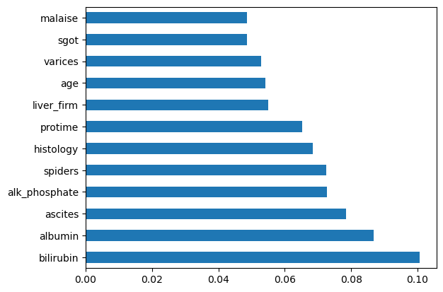

```python
feature_imporance_df.nlargest(12).plot(kind='barh')
```

#### Narrative

- All the methods gave us almost the same features to use

```python
# Correlation
df.corr()
```

|  | class | age | sex | steroid | antivirals | fatigue | malaise | anorexia | liver_big | liver_firm | spleen_palpable | spiders | ascites | varices | bilirubin | alk_phosphate | sgot | albumin | protime | histology |
| --- | --- | --- | --- | --- | --- | --- | --- | --- | --- | --- | --- | --- | --- | --- | --- | --- | --- | --- | --- | --- |
| class | 1.000000 | -0.219647 | 0.173051 | 0.121140 | -0.130196 | 0.292206 | 0.315970 | 0.110715 | 0.102151 | 0.154736 | 0.180894 | 0.330194 | 0.332796 | 0.249610 | -0.424523 | -0.050806 | -0.056679 | 0.296489 | 0.154688 | -0.337856 |
| age | -0.219647 | 1.000000 | 0.008126 | -0.067710 | -0.013100 | -0.264635 | -0.099516 | 0.100589 | -0.126358 | -0.100979 | -0.127258 | -0.206551 | -0.125020 | -0.114412 | 0.095626 | 0.045328 | 0.078021 | -0.191174 | -0.059956 | 0.170780 |
| sex | 0.173051 | 0.008126 | 1.000000 | -0.039222 | -0.089249 | -0.063947 | -0.020895 | 0.025186 | 0.023634 | 0.015750 | -0.078414 | -0.065592 | 0.049516 | -0.005045 | -0.039341 | 0.162851 | -0.008991 | -0.018906 | 0.067128 | -0.137450 |
| steroid | 0.121140 | -0.067710 | -0.039222 | 1.000000 | 0.101657 | 0.146292 | 0.232041 | 0.084752 | 0.159877 | 0.095280 | 0.071401 | 0.029781 | -0.002593 | -0.029759 | -0.005835 | -0.042245 | -0.021032 | 0.203109 | 0.032994 | -0.070144 |
| antivirals | -0.130196 | -0.013100 | -0.089249 | 0.101657 | 1.000000 | -0.065578 | -0.026703 | -0.052554 | -0.060626 | -0.019871 | -0.183070 | -0.176367 | -0.176382 | -0.167721 | 0.177958 | 0.041764 | 0.095980 | -0.153939 | -0.276452 | 0.209242 |
| fatigue | 0.292206 | -0.264635 | -0.063947 | 0.146292 | -0.065578 | 1.000000 | 0.617660 | 0.419991 | 0.168796 | 0.254621 | 0.226850 | 0.380935 | 0.288877 | 0.217311 | -0.243964 | -0.110505 | -0.175476 | 0.198983 | 0.073783 | -0.131177 |
| malaise | 0.315970 | -0.099516 | -0.020895 | 0.232041 | -0.026703 | 0.617660 | 1.000000 | 0.631662 | 0.192556 | 0.197903 | 0.145236 | 0.376666 | 0.376182 | 0.267029 | -0.269910 | -0.114810 | -0.177297 | 0.224605 | 0.067186 | -0.116964 |
| anorexia | 0.110715 | 0.100589 | 0.025186 | 0.084752 | -0.052554 | 0.419991 | 0.631662 | 1.000000 | 0.185164 | 0.144556 | 0.185004 | 0.371874 | 0.301514 | 0.288883 | -0.244095 | 0.035984 | -0.188183 | 0.133743 | 0.108322 | -0.049702 |
| liver_big | 0.102151 | -0.126358 | 0.023634 | 0.159877 | -0.060626 | 0.168796 | 0.192556 | 0.185164 | 1.000000 | 0.698517 | 0.338963 | 0.370229 | 0.339108 | 0.238645 | -0.028856 | 0.018895 | -0.026293 | 0.105555 | 0.174677 | -0.104757 |
| liver_firm | 0.154736 | -0.100979 | 0.015750 | 0.095280 | -0.019871 | 0.254621 | 0.197903 | 0.144556 | 0.698517 | 1.000000 | 0.322955 | 0.407114 | 0.310338 | 0.295100 | -0.069352 | -0.179977 | -0.149876 | 0.059700 | 0.083312 | -0.206632 |
| spleen_palpable | 0.180894 | -0.127258 | -0.078414 | 0.071401 | -0.183070 | 0.226850 | 0.145236 | 0.185004 | 0.338963 | 0.322955 | 1.000000 | 0.515462 | 0.495691 | 0.574616 | -0.178364 | -0.160211 | -0.116444 | 0.196297 | 0.124451 | -0.100840 |
| spiders | 0.330194 | -0.206551 | -0.065592 | 0.029781 | -0.176367 | 0.380935 | 0.376666 | 0.371874 | 0.370229 | 0.407114 | 0.515462 | 1.000000 | 0.553650 | 0.609491 | -0.241770 | -0.136225 | -0.180494 | 0.116063 | 0.204276 | -0.246077 |
| ascites | 0.332796 | -0.125020 | 0.049516 | -0.002593 | -0.176382 | 0.288877 | 0.376182 | 0.301514 | 0.339108 | 0.310338 | 0.495691 | 0.553650 | 1.000000 | 0.672806 | -0.254516 | -0.058935 | -0.125707 | 0.144217 | 0.120694 | -0.178075 |
| varices | 0.249610 | -0.114412 | -0.005045 | -0.029759 | -0.167721 | 0.217311 | 0.267029 | 0.288883 | 0.238645 | 0.295100 | 0.574616 | 0.609491 | 0.672806 | 1.000000 | -0.316209 | -0.148553 | -0.160748 | 0.125137 | 0.124468 | -0.178705 |
| bilirubin | -0.424523 | 0.095626 | -0.039341 | -0.005835 | 0.177958 | -0.243964 | -0.269910 | -0.244095 | -0.028856 | -0.069352 | -0.178364 | -0.241770 | -0.254516 | -0.316209 | 1.000000 | 0.074370 | 0.252921 | -0.064800 | -0.125245 | 0.261637 |
| alk_phosphate | -0.050806 | 0.045328 | 0.162851 | -0.042245 | 0.041764 | -0.110505 | -0.114810 | 0.035984 | 0.018895 | -0.179977 | -0.160211 | -0.136225 | -0.058935 | -0.148553 | 0.074370 | 1.000000 | 0.141202 | 0.103838 | 0.135946 | 0.126923 |
| sgot | -0.056679 | 0.078021 | -0.008991 | -0.021032 | 0.095980 | -0.175476 | -0.177297 | -0.188183 | -0.026293 | -0.149876 | -0.116444 | -0.180494 | -0.125707 | -0.160748 | 0.252921 | 0.141202 | 1.000000 | -0.079875 | -0.038869 | 0.138095 |
| albumin | 0.296489 | -0.191174 | -0.018906 | 0.203109 | -0.153939 | 0.198983 | 0.224605 | 0.133743 | 0.105555 | 0.059700 | 0.196297 | 0.116063 | 0.144217 | 0.125137 | -0.064800 | 0.103838 | -0.079875 | 1.000000 | 0.334765 | -0.135412 |
| protime | 0.154688 | -0.059956 | 0.067128 | 0.032994 | -0.276452 | 0.073783 | 0.067186 | 0.108322 | 0.174677 | 0.083312 | 0.124451 | 0.204276 | 0.120694 | 0.124468 | -0.125245 | 0.135946 | -0.038869 | 0.334765 | 1.000000 | -0.154030 |
| histology | -0.337856 | 0.170780 | -0.137450 | -0.070144 | 0.209242 | -0.131177 | -0.116964 | -0.049702 | -0.104757 | -0.206632 | -0.100840 | -0.246077 | -0.178075 | -0.178705 | 0.261637 | 0.126923 | 0.138095 | -0.135412 | -0.154030 | 1.000000 |

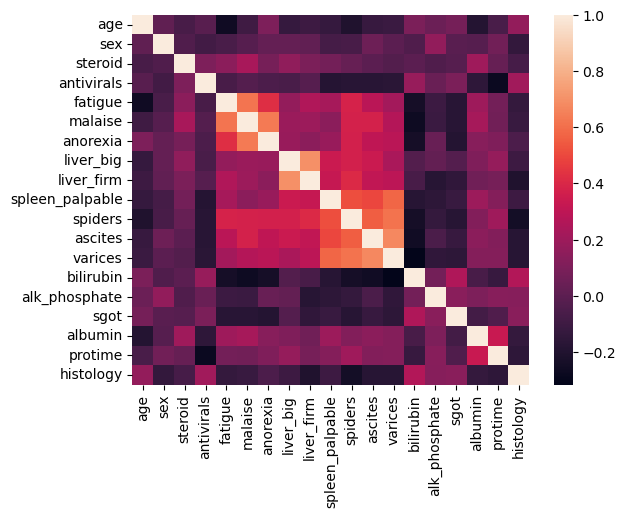

```python
# Heatmap for Correlation
sns.heatmap(xfeatures.corr())
```

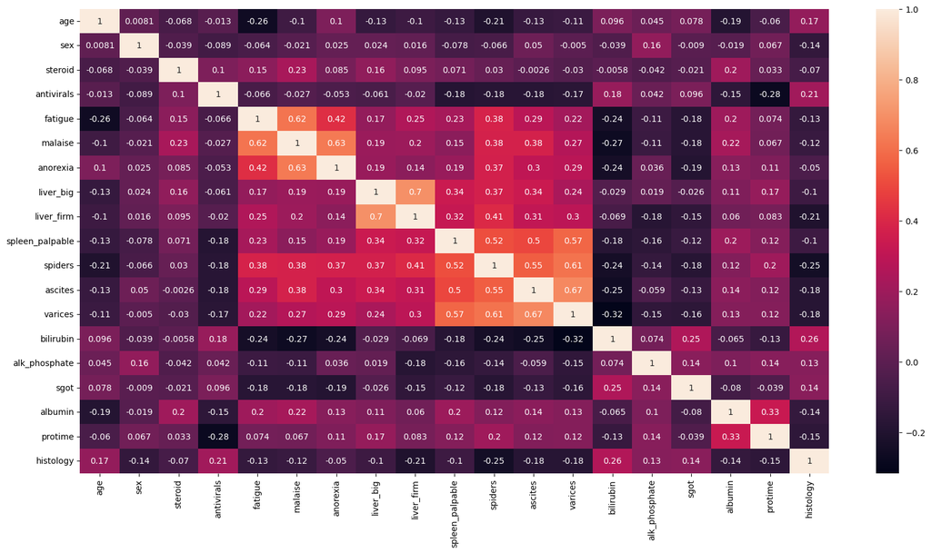

```python
# Heatmap for Correlation with Annot
plt.figure(figsize=(20,10))
sns.heatmap(xfeatures.corr(),annot=True)
plt.show()
```

### Model Building

- Feature & Labels
- Train/Test/Split
- LogisticRegression
- RF
- DCT
- Serialize

```python
# ML Pkg
from sklearn.linear_model import LogisticRegression
from sklearn.ensemble import RandomForestClassifier
from sklearn.tree import DecisionTreeClassifier

# Metrics
from sklearn.metrics import accuracy_score
from sklearn.model_selection import train_test_split
```

```python
# Features for Initial Data
df.columns
```

```
Index(['class', 'age', 'sex', 'steroid', 'antivirals', 'fatigue', 'malaise',
       'anorexia', 'liver_big', 'liver_firm', 'spleen_palpable', 'spiders',
       'ascites', 'varices', 'bilirubin', 'alk_phosphate', 'sgot', 'albumin',
       'protime', 'histology'],
      dtype='object')
```

```python
xfeatures
```

|  | age | sex | steroid | antivirals | fatigue | malaise | anorexia | liver_big | liver_firm | spleen_palpable | spiders | ascites | varices | bilirubin | alk_phosphate | sgot | albumin | protime | histology |
| --- | --- | --- | --- | --- | --- | --- | --- | --- | --- | --- | --- | --- | --- | --- | --- | --- | --- | --- | --- |
| 0 | 30 | 2 | 1 | 2 | 2 | 2 | 2 | 1 | 2 | 2 | 2 | 2 | 2 | 1.0 | 85 | 18 | 4.0 | 0 | 1 |
| 1 | 50 | 1 | 1 | 2 | 1 | 2 | 2 | 1 | 2 | 2 | 2 | 2 | 2 | 0.9 | 135 | 42 | 3.5 | 0 | 1 |
| 2 | 78 | 1 | 2 | 2 | 1 | 2 | 2 | 2 | 2 | 2 | 2 | 2 | 2 | 0.7 | 96 | 32 | 4.0 | 0 | 1 |
| 3 | 31 | 1 | 0 | 1 | 2 | 2 | 2 | 2 | 2 | 2 | 2 | 2 | 2 | 0.7 | 46 | 52 | 4.0 | 80 | 1 |
| 4 | 34 | 1 | 2 | 2 | 2 | 2 | 2 | 2 | 2 | 2 | 2 | 2 | 2 | 1.0 | 0 | 200 | 4.0 | 0 | 1 |
| ... | ... | ... | ... | ... | ... | ... | ... | ... | ... | ... | ... | ... | ... | ... | ... | ... | ... | ... | ... |
| 150 | 46 | 1 | 2 | 2 | 1 | 1 | 1 | 2 | 2 | 2 | 1 | 1 | 1 | 7.6 | 0 | 242 | 3.3 | 50 | 2 |
| 151 | 44 | 1 | 2 | 2 | 1 | 2 | 2 | 2 | 1 | 2 | 2 | 2 | 2 | 0.9 | 126 | 142 | 4.3 | 0 | 2 |
| 152 | 61 | 1 | 1 | 2 | 1 | 1 | 2 | 1 | 1 | 2 | 1 | 2 | 2 | 0.8 | 75 | 20 | 4.1 | 0 | 2 |
| 153 | 53 | 2 | 1 | 2 | 1 | 2 | 2 | 2 | 2 | 1 | 1 | 2 | 1 | 1.5 | 81 | 19 | 4.1 | 48 | 2 |
| 154 | 43 | 1 | 2 | 2 | 1 | 2 | 2 | 2 | 2 | 1 | 1 | 1 | 2 | 1.2 | 100 | 19 | 3.1 | 42 | 2 |

155 rows × 19 columns

```python
ylabels = df['class']
```

```python
# Selected Features
df.columns
```

```
Index(['class', 'age', 'sex', 'steroid', 'antivirals', 'fatigue', 'malaise',
       'anorexia', 'liver_big', 'liver_firm', 'spleen_palpable', 'spiders',
       'ascites', 'varices', 'bilirubin', 'alk_phosphate', 'sgot', 'albumin',
       'protime', 'histology'],
      dtype='object')
```

```python
xfeatures_best = df[['age', 'sex', 'steroid', 'antivirals','fatigue','spiders',
       'ascites', 'varices', 'bilirubin', 'alk_phosphate', 'sgot', 'albumin',
       'protime', 'histology']]
```

```python
# train /test dataset
x_train,x_test,y_train,y_test = train_test_split(xfeatures,ylabels,test_size=0.30,random_state=7)
```

```python
# train /test dataset for best features
x_train_b,x_test_b,y_train_b,y_test_b = train_test_split(xfeatures_best,ylabels,test_size=0.30,random_state=7)
```

```python
# Building Model
logreg = LogisticRegression()
logreg.fit(x_train,y_train)
```

```
LogisticRegression()
```

```python
# Model Accuracy
# Method 1
logreg.score(x_test,y_test)
```

```
0.723404255319149
```

```python
# Method 2
logreg.predict(x_test)
```

```
array([2, 2, 2, 2, 2, 1, 2, 2, 2, 2, 1, 2, 2, 2, 2, 2, 2, 2, 2, 2, 2, 2,
       2, 2, 2, 1, 2, 2, 2, 2, 2, 2, 2, 2, 2, 2, 2, 1, 2, 2, 2, 2, 2, 2,
       2, 2, 2], dtype=int64)
```

```python
print(list(y_test))
```

```
[2, 1, 2, 2, 2, 1, 1, 2, 2, 2, 1, 1, 2, 2, 2, 2, 1, 2, 2, 1, 2, 2, 1, 2, 2, 2, 1, 2, 1, 2, 2, 2, 2, 2, 2, 2, 2, 2, 2, 2, 2, 2, 1, 1, 2, 1, 2]
```

```python
accuracy_score(y_test,logreg.predict(x_test))
```

```
0.723404255319149
```

```python
# Building Model
model_logit = LogisticRegression()
model_logit.fit(x_train_b,y_train_b)
```

```
LogisticRegression()
```

```python
# Model Accuracy
# Method 1
model_logit.score(x_test_b,y_test_b)
```

```
0.723404255319149
```

```python
### Single Prediction
x_test.iloc[1]
```

```
age                 58.0
sex                  1.0
steroid              2.0
antivirals           2.0
fatigue              1.0
malaise              2.0
anorexia             2.0
liver_big            1.0
liver_firm           1.0
spleen_palpable      1.0
spiders              1.0
ascites              2.0
varices              2.0
bilirubin            2.0
alk_phosphate      167.0
sgot               242.0
albumin              3.3
protime              0.0
histology            1.0
Name: 76, dtype: float64
```

```python
res_dic = {"Die":1,"Live":2}
x1 = x_test.iloc[1]
```

```python
# Reshaping
logreg.predict(np.array(x1).reshape(1,-1))
```

```
array([2], dtype=int64)
```

### Alternative Algorithms

```python
clf = DecisionTreeClassifier()
```

```python
# Fit
clf.fit(x_train_b,y_train_b)
```

```
DecisionTreeClassifier()
```

```python
# Model Accuracy Score
clf.score(x_test_b,y_test_b)
```

```
0.7659574468085106
```

```python
# KNN
from sklearn.neighbors import KNeighborsClassifier
```

```python
knn = KNeighborsClassifier(n_neighbors=3)
```

```python
# Fit
knn.fit(x_train_b,y_train_b)
```

```
KNeighborsClassifier(n_neighbors=3)
```

```python
# Model Accuracy Score
knn.score(x_test_b,y_test_b)
```

```
0.7446808510638298
```